# CART & RF

Daniel Fernández

04 March 2022

In this practice, we are going to see all the methods that have been explained in the first part of the class. For this, we will use various databases that will help us better exemplify each of the classification and regression tree methods.

We always start by deleting all the possible objects of R that could have been left in memory.

```r
rm(list = ls())
```

### Getting the dataset and pre-processing

First, as always, we load the packages we will need.

The package *rpart* runs CART, *dplyr* and *ggplot2* will help us with data manipulation and graphs, and *kableExtra* will help us to print beautiful tables.

```r
library(rpart)
library(dplyr)
library(ggplot2)
library(kableExtra)
```

The problem we want to solve is to build a classification tree model that can *differentiate between spam and non-spam email*.

The database and its documentation can be obtained from (Blake and Mers (1998) UC Irvine Machine Learning):

https://archive.ics.uci.edu/ml/datasets/spambase

[figure not shown]

This data set has several variables/features for each person (case).

It has 4601 emails of which 1813 were identified as spam. This is identified with a binary response variable labeled as a *yesno* (spam e-mail yes or no) and we are going to use 6 descriptive variables:

- crl.tot: number of words in uppercase
- dollar: the frequency of the $ symbol, as a percentage of all characters
- bang: the frequency of the! symbol, as a percentage of all characters
- money: the frequency of the word “money”, as a percentage of all characters
- n000: the frequency of the word “000”, as a percentage of all characters
- make: the frequency of the word “make”, as a percentage of all characters

We want to create a classification tree that gives us the rules to classify an email as spam or not depending on the 6 descriptive variables above. For this we will use the R package *rpart*

We have downloaded the database in comma separated text (CSV) format from the web and we read it from our local folder.

```r
spam <- read.csv("spambase.csv", dec=",", header=FALSE)
```

The original database has many variables (you can read it in the database documentation). We assign the name of the variables:

```r
newColNames <- c("make", "word_freq_address", "word_freq_all", "word_freq_3d", "word_freq_our", "word_freq_over", "word_freq_remove", "word_freq_internet", "word_freq_order", "word_freq_mail", "word_freq_receive", "word_freq_will","word_freq_people", "word_freq_report", "word_freq_addresses", "word_freq_free", "word_freq_business", "word_freq_email", "word_freq_you", "word_freq_credit",  "word_freq_your", "word_freq_font", "n000", "money",  "word_freq_hp", "word_freq_hpl", "word_freq_george", "word_freq_650", "word_freq_lab", "word_freq_labs", "word_freq_telnet", "word_freq_857", "word_freq_data", "word_freq_415", "word_freq_85", "word_freq_technology", "word_freq_1999",  "word_freq_parts", "word_freq_pm", "word_freq_direct", "word_freq_cs", "word_freq_meeting",
 "word_freq_original", "word_freq_project", "word_freq_re", "word_freq_edu",  "word_freq_table", "word_freq_conference", "char_freq_ch;", "char_freq_ch(",  "char_freq_ch[", "bang", "dollar", "char_freq_ch#", "capital_run_length_average",  "capital_run_length_longest", "crl.tot", "yesno")

colnames(spam) <- newColNames
```

And we select the 7 variables that interest us

```r
spam7 <- spam[,c( "yesno", "crl.tot", "dollar", "bang", "money", "n000", "make")]
head(spam7)
```

```
##   yesno crl.tot dollar  bang money n000 make
## 1     1     278      0 0.778     0    0    0
## 2     1    1028   0.18 0.372  0.43 0.43 0.21
## 3     1    2259  0.184 0.276  0.06 1.16 0.06
## 4     1     191      0 0.137     0    0    0
## 5     1     191      0 0.135     0    0    0
## 6     1      54      0     0     0    0    0
```

We check the structure of the chosen data set

```r
str(spam7)
```

```
## 'data.frame':    4601 obs. of  7 variables:
##  $ yesno  : int  1 1 1 1 1 1 1 1 1 1 ...
##  $ crl.tot: int  278 1028 2259 191 191 54 112 49 1257 749 ...
##  $ dollar : chr  "0" "0.18" "0.184" "0" ...
##  $ bang   : chr  "0.778" "0.372" "0.276" "0.137" ...
##  $ money  : chr  "0" "0.43" "0.06" "0" ...
##  $ n000   : chr  "0" "0.43" "1.16" "0" ...
##  $ make   : chr  "0" "0.21" "0.06" "0" ...
```

R read some numeric variables as characters, let’s set them as numeric using the command *as.numeric()*:

```r
spam7$dollar <- as.numeric(spam7$dollar)
spam7$bang <- as.numeric(spam7$bang)
spam7$money <- as.numeric(spam7$money)
spam7$n000 <- as.numeric(spam7$n000)
spam7$make <- as.numeric(spam7$make)
```

We change the binary response variable *spam7* to factor:

```r
table(spam7$yesno)
```

```
##
##    0    1
## 2788 1813
```

```r
spam7$yesno <- as.factor(ifelse(spam7$yesno<1,"no","yes"))
```

Let’s check that all type changes has been done in a correct way

```r
table(spam7$yesno)
```

```
##
##   no  yes
## 2788 1813
```

We check the structure of the data set again to see that all changes performed were applied:

```r
str(spam7)
```

```
## 'data.frame':    4601 obs. of  7 variables:
##  $ yesno  : Factor w/ 2 levels "no","yes": 2 2 2 2 2 2 2 2 2 2 ...
##  $ crl.tot: int  278 1028 2259 191 191 54 112 49 1257 749 ...
##  $ dollar : num  0 0.18 0.184 0 0 0 0.054 0 0.203 0.081 ...
##  $ bang   : num  0.778 0.372 0.276 0.137 0.135 0 0.164 0 0.181 0.244 ...
##  $ money  : num  0 0.43 0.06 0 0 0 0 0 0.15 0 ...
##  $ n000   : num  0 0.43 1.16 0 0 0 0 0 0 0.19 ...
##  $ make   : num  0 0.21 0.06 0 0 0 0 0 0.15 0.06 ...
```

### Exploring the data set

```r
spam7 %>%
  sample_n(., 20, replace=FALSE) %>%
  arrange(yesno) %>%
  kbl(caption = "Spam data set (sample of 20)") %>%
  kable_classic(full_width = F, html_font = "Cambria")
```

Spam data set (sample of 20)

| yesno | crl.tot | dollar | bang | money | n000 | make |
| --- | --- | --- | --- | --- | --- | --- |
| no | 74 | 0.000 | 0.055 | 0.00 | 0 | 0.30 |
| no | 117 | 0.000 | 0.000 | 0.00 | 0 | 0.00 |
| no | 147 | 0.000 | 0.068 | 0.00 | 0 | 0.00 |
| no | 45 | 0.000 | 0.403 | 0.00 | 0 | 0.00 |
| no | 3 | 0.000 | 0.000 | 0.00 | 0 | 0.00 |
| no | 70 | 0.000 | 0.098 | 0.61 | 0 | 0.00 |
| yes | 46 | 0.000 | 0.000 | 0.00 | 0 | 0.00 |
| yes | 111 | 0.077 | 0.544 | 0.00 | 0 | 0.49 |
| yes | 78 | 0.000 | 0.000 | 1.88 | 0 | 0.00 |
| yes | 102 | 0.000 | 0.000 | 0.00 | 0 | 0.00 |
| yes | 757 | 1.313 | 5.848 | 0.09 | 0 | 0.09 |
| yes | 23 | 0.000 | 1.336 | 0.00 | 0 | 0.00 |
| yes | 400 | 0.127 | 0.204 | 0.44 | 0 | 0.14 |
| yes | 113 | 0.000 | 1.461 | 0.00 | 0 | 0.00 |
| yes | 118 | 0.000 | 0.834 | 0.00 | 0 | 0.00 |
| yes | 43 | 0.000 | 0.311 | 0.00 | 0 | 0.53 |
| yes | 93 | 0.223 | 0.223 | 0.74 | 0 | 0.00 |
| yes | 15 | 0.000 | 7.843 | 0.00 | 0 | 0.00 |
| yes | 249 | 0.129 | 0.776 | 0.84 | 0 | 0.00 |
| yes | 131 | 0.000 | 0.000 | 2.32 | 0 | 0.00 |

Let’s do a little bit of Exploratory Data Analysis (EDA)

We can calculate basic statistics on each of the data frame’s columns with *summary*

```r
spam7 %>%
  summary(.) %>%
  kbl(caption = "Basic statistics. Spam data set") %>%
  kable_classic(full_width = F, html_font = "Cambria")
```

Basic statistics. Spam data set

|  | yesno | crl.tot | dollar | bang | money | n000 | make |
| --- | --- | --- | --- | --- | --- | --- | --- |
|  | no :2788 | Min. : 1.0 | Min. :0.00000 | Min. : 0.0000 | Min. : 0.00000 | Min. :0.0000 | Min. :0.0000 |
|  | yes:1813 | 1st Qu.: 35.0 | 1st Qu.:0.00000 | 1st Qu.: 0.0000 | 1st Qu.: 0.00000 | 1st Qu.:0.0000 | 1st Qu.:0.0000 |
|  | NA | Median : 95.0 | Median :0.00000 | Median : 0.0000 | Median : 0.00000 | Median :0.0000 | Median :0.0000 |
|  | NA | Mean : 283.3 | Mean :0.07581 | Mean : 0.2691 | Mean : 0.09427 | Mean :0.1016 | Mean :0.1046 |
|  | NA | 3rd Qu.: 266.0 | 3rd Qu.:0.05200 | 3rd Qu.: 0.3150 | 3rd Qu.: 0.00000 | 3rd Qu.:0.0000 | 3rd Qu.:0.0000 |
|  | NA | Max. :15841.0 | Max. :6.00300 | Max. :32.4780 | Max. :12.50000 | Max. :5.4500 | Max. :4.5400 |

There are no missing values.

We roughly check the distributions (*avoiding the zeros* as they dominate the variables. That’s normal (there are more e-mails no spam))

```r
library(gridExtra)
```

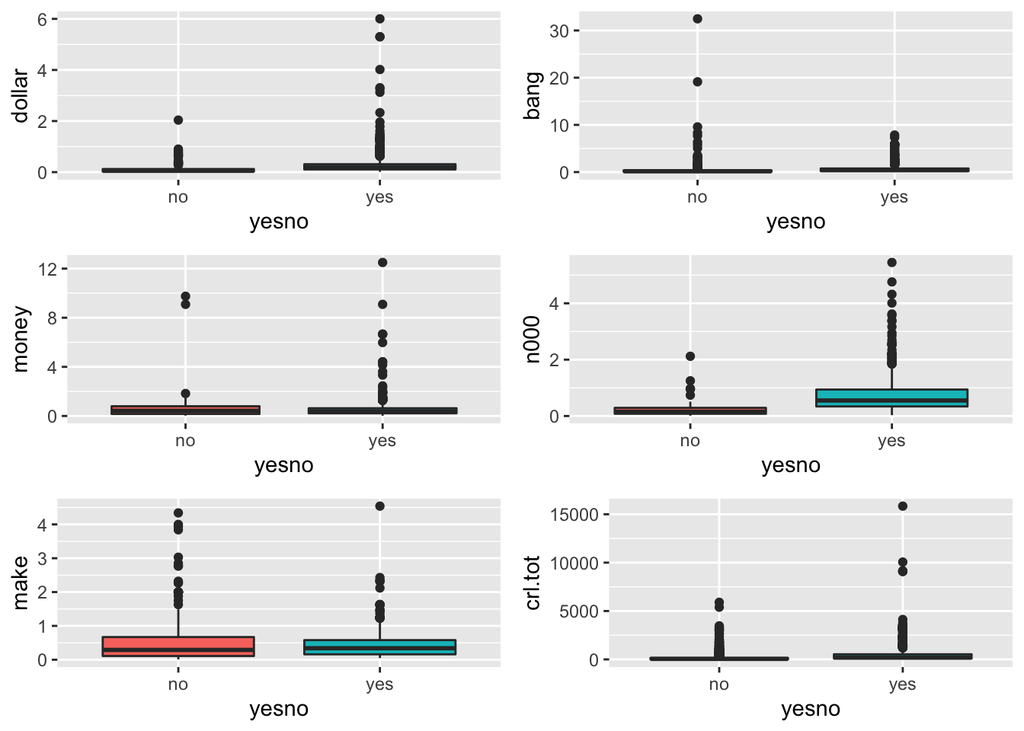

```r
g1 <- spam7 %>%
      filter(dollar>0) %>%
      ggplot(.,aes(x=yesno, y=dollar, fill=yesno)) +
      geom_boxplot() +
      theme(legend.position="none")
g2 <- spam7 %>%
      filter(bang>0) %>%
      ggplot(.,aes(x=yesno, y=bang, fill=yesno)) +
      geom_boxplot() +
      theme(legend.position="none")
g3 <- spam7 %>%
      filter(money>0) %>%
      ggplot(.,aes(x=yesno, y=money, fill=yesno)) +
      geom_boxplot() +
      theme(legend.position="none")
g4 <- spam7 %>%
      filter(n000>0) %>%
      ggplot(.,aes(x=yesno, y=n000, fill=yesno)) +
      geom_boxplot() +
      theme(legend.position="none")
g5 <- spam7 %>%
      filter(make>0) %>%
      ggplot(.,aes(x=yesno, y=make, fill=yesno)) +
      geom_boxplot() +
      theme(legend.position="none")
g6 <- spam7 %>%
      filter(crl.tot>0) %>%
      ggplot(.,aes(x=yesno, y=crl.tot, fill=yesno)) +
      geom_boxplot() +
      theme(legend.position="none")

grid.arrange(g1,g2,g3,g4,g5,g6,nrow=3)
```

There are possible outliers but it is not implausible to get those higher values in an e-mail. Therefore, we left them

*Note*: We skip here that part of more analyses for the sake of having more time to work on CART and RF. You can do similar things to the ones we did in PCA or LDA sessions (histograms, correlations, missing values,…).

### Running first Classification Tree (all data set)

We fit the classification tree model using all the descriptive variables. *method = “class”* is used for classification tree

```r
spam.class <- rpart(formula= yesno ~ crl.tot + dollar + bang + money + n000 + make, method="class", data=spam7)
summary(spam.class)
```

```
## Call:
## rpart(formula = yesno ~ crl.tot + dollar + bang + money + n000 +
##     make, data = spam7, method = "class")
##   n= 4601
##
##           CP nsplit rel error    xerror       xstd
## 1 0.47655819      0 1.0000000 1.0000000 0.01828190
## 2 0.07556536      1 0.5234418 0.5399890 0.01531234
## 3 0.01158301      3 0.3723111 0.3844457 0.01341366
## 4 0.01047987      4 0.3607281 0.3816878 0.01337402
## 5 0.01000000      5 0.3502482 0.3783784 0.01332613
##
## Variable importance
##  dollar    bang   money    n000 crl.tot    make
##      40      17      15      15      12       2
##
## Node number 1: 4601 observations,    complexity param=0.4765582
##   predicted class=no   expected loss=0.3940448  P(node) =1
##     class counts:  2788  1813
##    probabilities: 0.606 0.394
##   left son=2 (3471 obs) right son=3 (1130 obs)
##   Primary splits:
##       dollar  < 0.0555 to the left,  improve=714.1697, (0 missing)
##       bang    < 0.0795 to the left,  improve=711.9638, (0 missing)
##       money   < 0.01   to the left,  improve=496.0482, (0 missing)
##       n000    < 0.125  to the left,  improve=398.2549, (0 missing)
##       crl.tot < 71.5   to the left,  improve=347.1149, (0 missing)
##   Surrogate splits:
##       n000    < 0.055  to the left,  agree=0.839, adj=0.346, (0 split)
##       money   < 0.045  to the left,  agree=0.833, adj=0.321, (0 split)
##       crl.tot < 693.5  to the left,  agree=0.790, adj=0.143, (0 split)
##       make    < 0.315  to the left,  agree=0.762, adj=0.030, (0 split)
##
## Node number 2: 3471 observations,    complexity param=0.07556536
##   predicted class=no   expected loss=0.2350908  P(node) =0.7544012
##     class counts:  2655   816
##    probabilities: 0.765 0.235
##   left son=4 (2420 obs) right son=5 (1051 obs)
##   Primary splits:
##       bang    < 0.0915 to the left,  improve=284.61340, (0 missing)
```

[output cut: 68 more lines]

```
##       crl.tot < 17     to the left,  improve=13.123870, (0 missing)
##       bang    < 5.027  to the right, improve= 2.440427, (0 missing)
##       make    < 0.14   to the left,  improve= 0.230969, (0 missing)
##   Surrogate splits:
##       bang < 2.9455 to the right, agree=0.641, adj=0.023, (0 split)
##
## Node number 42: 43 observations
##   predicted class=no   expected loss=0.2790698  P(node) =0.009345794
##     class counts:    31    12
##    probabilities: 0.721 0.279
##
## Node number 43: 74 observations
##   predicted class=yes  expected loss=0.2297297  P(node) =0.01608346
##     class counts:    17    57
##    probabilities: 0.230 0.770
```

The *summary* is displaying the tree in text format. As we can see, it is difficult to clearly appreciate the rules. Better to use some visual tool.

Thus, we draw the classification tree and add the text / labels to it:

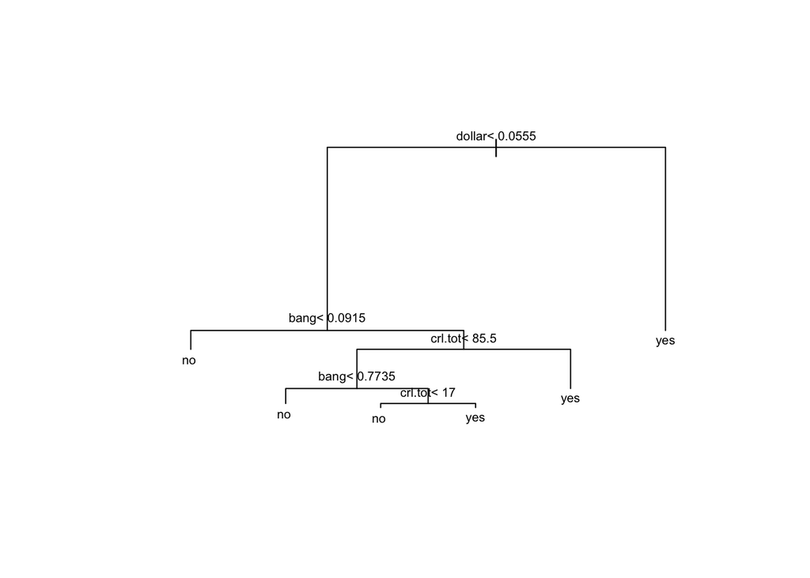

```r
plot(spam.class, margin=0.15)
text(spam.class,cex=0.65)
```

If we use the parameter *use.n = TRUE* we obtain the number of observations per node.

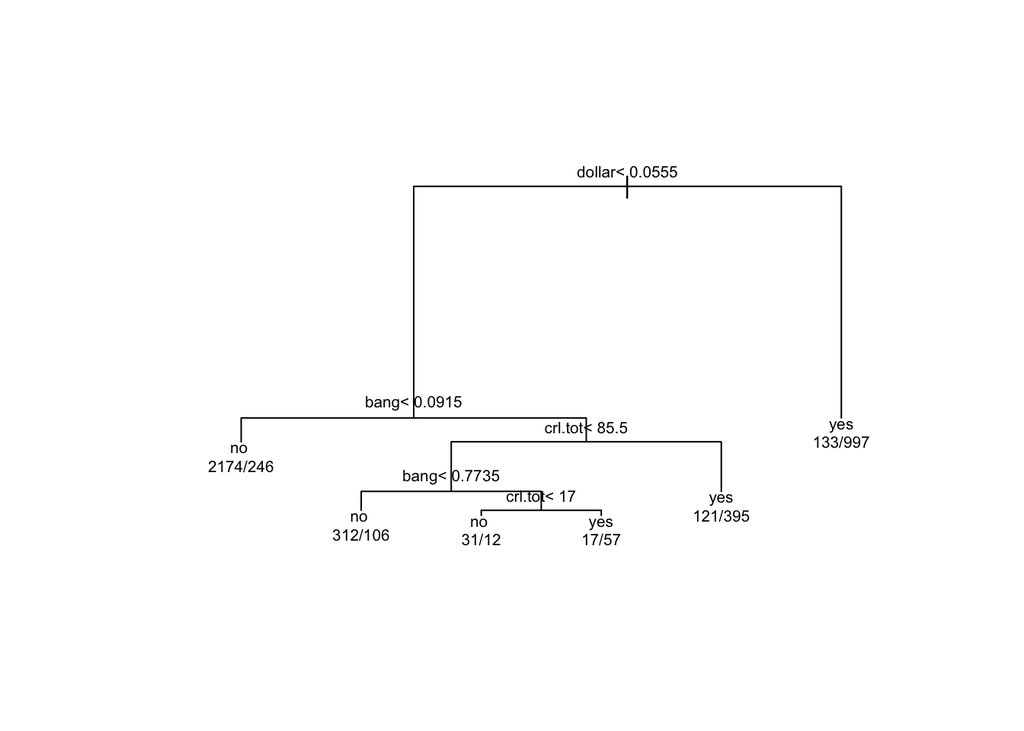

```r
plot(spam.class, margin=0.15)
text(spam.class,cex=0.65, use.n=TRUE)
```

If we use the *uniform = TRUE* parameter, the distance between nodes is controlled and the graph will probably be better visualized

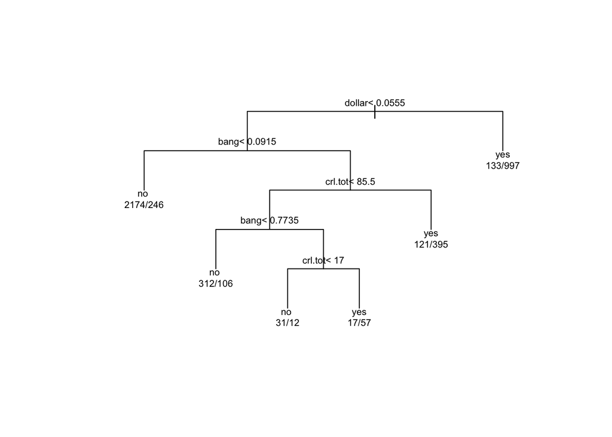

```r
plot(spam.class, margin=0.15, uniform=TRUE)
text(spam.class,cex=0.65, use.n=TRUE)
```

In each division, the observations for which the condition is fulfilled take the branch to the left. For example, dollar <0.0555 and bang <0.0915 lead to the prediction that the email is not spam. The terminal nodes are called “leaves”. The number of splits is the size of the trees and is always one minus the number of leaves.

### Prediction

Firstly, as we explained in class, we split the data into training set (80%) and test set (20%):

```r
library(caret)
set.seed(123)
training.samples <- spam7$yesno %>%
      createDataPartition(p = 0.8, list = FALSE)

train.spam7 <- spam7[training.samples, ]
test.spam7 <- spam7[-training.samples, ]
paste0("Proportion of training is ", round((nrow(train.spam7)/nrow(spam7))*100,2),"%")
```

```
## [1] "Proportion of training is 80.03%"
```

```r
paste0("Proportion of test is ", round((nrow(test.spam7)/nrow(spam7))*100,2),"%")
```

```
## [1] "Proportion of test is 19.97%"
```

We model the classification tree with the subset of **training** data

```r
spam.tree.train <- rpart(formula= yesno ~ crl.tot + dollar + bang + money + n000 + make, method="class", data=train.spam7)
```

and we graph

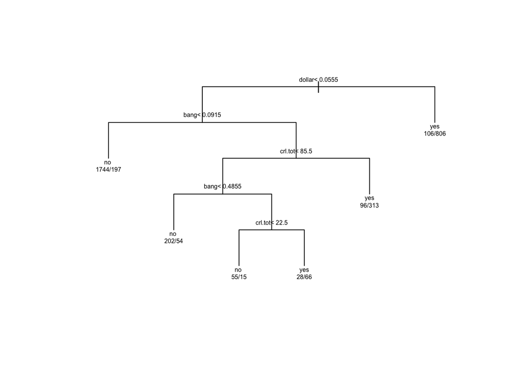

```r
plot(spam.tree.train, uniform=TRUE, margin=0.1)
text(spam.tree.train,cex=0.5, use.n=TRUE)
```

Now we have the “trained” classification tree and we are going to use it with the **test** database to validate that it predicts correctly. For this we use the function *predict (trained_object, test_data)*

Note: I put it as a percentage to make it look better

```r
predicted <- round(predict(spam.tree.train,test.spam7),4)*100
head(predicted)
```

```
##       no   yes
## 6  89.85 10.15
## 8  89.85 10.15
## 13 23.47 76.53
## 19 78.91 21.09
## 23 29.79 70.21
## 29 78.91 21.09
```

```r
nrow(predicted)
```

```
## [1] 919
```

We put it all together using *data.frame* to show the real/truth and the prediction:

```r
predicted.vs.real <- data.frame(predicted, test.spam7$yesno)
predicted.vs.real[sample(nrow(predicted),10),]
```

```
##         no   yes test.spam7.yesno
## 1367 11.62 88.38              yes
## 2790 89.85 10.15               no
## 2349 89.85 10.15               no
## 2898 89.85 10.15               no
## 3592 89.85 10.15               no
## 4514 89.85 10.15               no
## 2224 89.85 10.15               no
## 1550 11.62 88.38              yes
## 1069 11.62 88.38              yes
## 2748 89.85 10.15               no
```

We can also do a crosstable to see the results:

```r
pred.spam <- ifelse(predicted.vs.real[,"no"]>predicted.vs.real[,"yes"],"no","yes")
results <- table(pred.spam,test.spam7$yesno)
results
```

```
##
## pred.spam  no yes
##       no  496  71
##       yes  61 291
```

And therefore the percentage of success/accuracy of the tree is:

```r
(results[1,1] + results[2,2])/sum(results) * 100
```

```
## [1] 85.63656
```

which is quite high, i.e. there is a 14.36% error, which is quiet good.

### Random Forest

We are going to build a random forest model that can solve the same problem than in the previous section: build descriptive variable rules to classify e-mails as spam or not.

We have to use the package *randomForest*:

```r
library(randomForest)
```

As a remark the *randomForest()* function requires that the *response variable is in numeric form*. Thus, we transform it into both the training set and the test that we have built in the previous section:

```r
train.spam7.rf <- train.spam7
test.spam7.rf <- test.spam7
head(train.spam7.rf$yesno)
```

```
## [1] yes yes yes yes yes yes
## Levels: no yes
```

```r
head(test.spam7.rf$yesno)
```

```
## [1] yes yes yes yes yes yes
## Levels: no yes
```

```r
train.spam7.rf$yesno <- ifelse(train.spam7.rf$yesno=="yes",1,0)
test.spam7.rf$yesno <- ifelse(test.spam7.rf$yesno=="yes",1,0)

train.spam7.rf$yesno <- as.factor(train.spam7.rf$yesno)
test.spam7.rf$yesno <- as.factor(test.spam7.rf$yesno)
```

We check that the transformation has no problems:

```r
table(train.spam7$yesno,train.spam7.rf$yesno)
```

```
##
##          0    1
##   no  2231    0
##   yes    0 1451
```

```r
table(test.spam7$yesno,test.spam7.rf$yesno)
```

```
##
##         0   1
##   no  557   0
##   yes   0 362
```

Now, we run the Random Forest:

```r
rf.train <- randomForest(yesno ~ ., data=train.spam7.rf, ntree=200)
print(rf.train)
```

```
##
## Call:
##  randomForest(formula = yesno ~ ., data = train.spam7.rf, ntree = 200)
##                Type of random forest: classification
##                      Number of trees: 200
## No. of variables tried at each split: 2
##
##         OOB estimate of  error rate: 11.79%
## Confusion matrix:
##      0    1 class.error
## 0 2120  111  0.04975347
## 1  323 1128  0.22260510
```

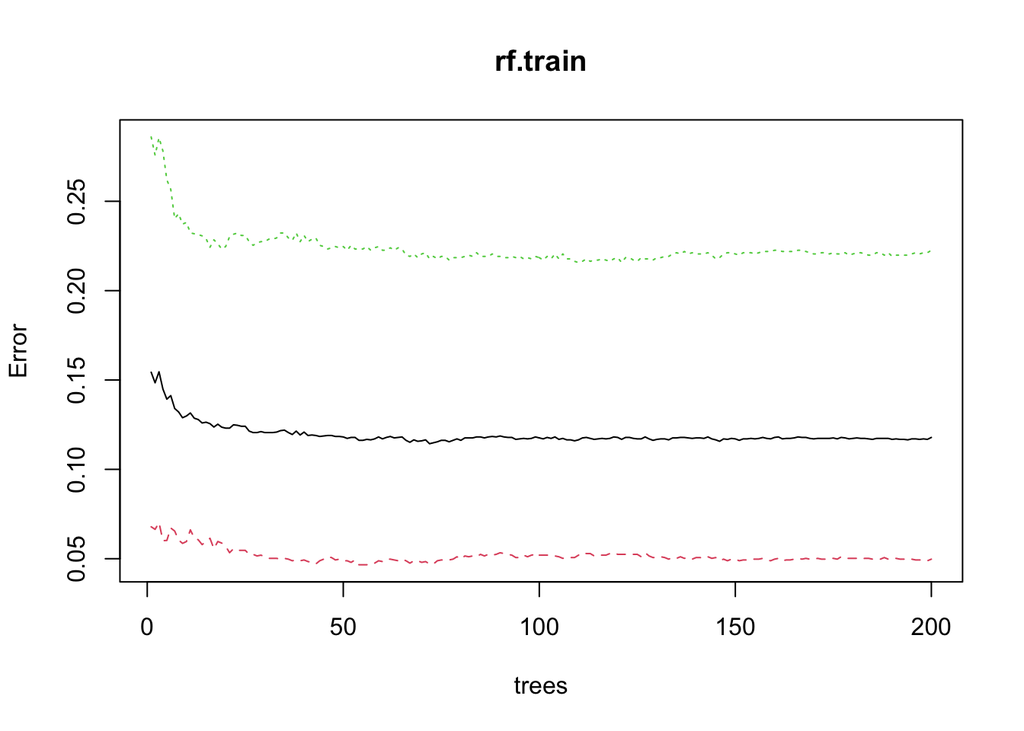

```r
plot(rf.train)
```

It is observed that the more trees the less error.

#### Prediction in RF

As before, let’s check the prediction over the test data set:

```r
predicted <- predict(rf.train,test.spam7.rf)
head(predicted)
```

```
##  6  8 13 19 23 29
##  0  0  1  0  1  0
## Levels: 0 1
```

```r
length(predicted)
```

```
## [1] 919
```

```r
pred.spam.rf <- ifelse(predicted==0,"no","yes")
results.rf <- table(pred.spam.rf,test.spam7.rf$yesno)
results.rf
```

```
##
## pred.spam.rf   0   1
##          no  531  88
##          yes  26 274
```

```r
(results.rf[1,1] + results.rf[2,2])/sum(results.rf) * 100
```

```
## [1] 87.59521
```

which logically is higher than previously with a classification tree (85.64%).

We can change *the number of trees* the random forest can use and see if we get better. We can also force to *select more variables* for each tree (parameter *mtry*). We were doing 2 so far (*No. of variables tried at each split: 2*). Let’s try with 4.

```r
rf.train2<- randomForest(yesno ~ ., data=train.spam7.rf, ntree=200, mtry=4)
print(rf.train2)
```

```
##
## Call:
##  randomForest(formula = yesno ~ ., data = train.spam7.rf, ntree = 200,      mtry = 4)
##                Type of random forest: classification
##                      Number of trees: 200
## No. of variables tried at each split: 4
##
##         OOB estimate of  error rate: 11.98%
## Confusion matrix:
##      0    1 class.error
## 0 2083  148  0.06633797
## 1  293 1158  0.20192970
```

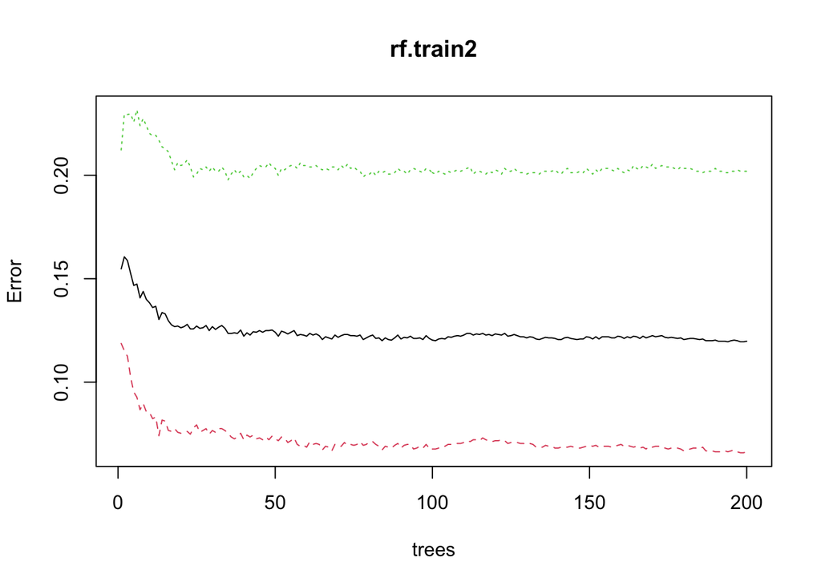

```r
plot(rf.train2)
```

The more trees, the less error.

Let’s see what happens with the prediction (as before):

```r
predicted2 <- predict(rf.train2,test.spam7.rf)
head(predicted2)
```

```
##  6  8 13 19 23 29
##  0  0  1  1  1  0
## Levels: 0 1
```

```r
length(predicted2)
```

```
## [1] 919
```

```r
pred.spam.rf2 <- ifelse(predicted2==0,"no","yes")
results.rf2 <- table(pred.spam.rf2,test.spam7.rf$yesno)
results.rf2
```

```
##
## pred.spam.rf2   0   1
##           no  522  73
##           yes  35 289
```

```r
(results.rf2[1,1] + results.rf2[2,2])/sum(results.rf2) * 100
```

```
## [1] 88.2481
```

which is close (but better) to the previous random forest (87.6%).

### Regression Trees

We have the data set **car.test.frame** included in the *rpart* package.

It is composed of 60 car brands & 8 variables:

```r
str(car.test.frame)
```

```
## 'data.frame':    60 obs. of  8 variables:
##  $ Price      : int  8895 7402 6319 6635 6599 8672 7399 7254 9599 5866 ...
##  $ Country    : Factor w/ 8 levels "France","Germany",..: 8 8 5 4 3 6 4 5 3 3 ...
##  $ Reliability: int  4 2 4 5 5 4 5 1 5 NA ...
##  $ Mileage    : int  33 33 37 32 32 26 33 28 25 34 ...
##  $ Type       : Factor w/ 6 levels "Compact","Large",..: 4 4 4 4 4 4 4 4 4 4 ...
##  $ Weight     : int  2560 2345 1845 2260 2440 2285 2275 2350 2295 1900 ...
##  $ Disp.      : int  97 114 81 91 113 97 97 98 109 73 ...
##  $ HP         : int  113 90 63 92 103 82 90 74 90 73 ...
```

```r
dim(car.test.frame)
```

```
## [1] 60  8
```

It contains the price, country, weight, mileage… and more variables.

```r
head(car.test.frame) %>%
  kbl(caption = "Cars data set. First 6 rows") %>%
  kable_classic(full_width = F, html_font = "Cambria")
```

Cars data set. First 6 rows

|  | Price | Country | Reliability | Mileage | Type | Weight | Disp. | HP |
| --- | --- | --- | --- | --- | --- | --- | --- | --- |
| Eagle Summit 4 | 8895 | USA | 4 | 33 | Small | 2560 | 97 | 113 |
| Ford Escort 4 | 7402 | USA | 2 | 33 | Small | 2345 | 114 | 90 |
| Ford Festiva 4 | 6319 | Korea | 4 | 37 | Small | 1845 | 81 | 63 |
| Honda Civic 4 | 6635 | Japan/USA | 5 | 32 | Small | 2260 | 91 | 92 |
| Mazda Protege 4 | 6599 | Japan | 5 | 32 | Small | 2440 | 113 | 103 |
| Mercury Tracer 4 | 8672 | Mexico | 4 | 26 | Small | 2285 | 97 | 82 |

We are going to apply a regression tree for the dependent variable Mileage (numeric) and the independent variables Weight, Price and Reliability.

For this, the option *method = “anova”* is used to indicate to generate a regression tree

```r
car.tree <- rpart(formula=  Mileage ~ Weight + Price + Reliability,
                    method="anova", data=car.test.frame)
```

We depict the regression tree

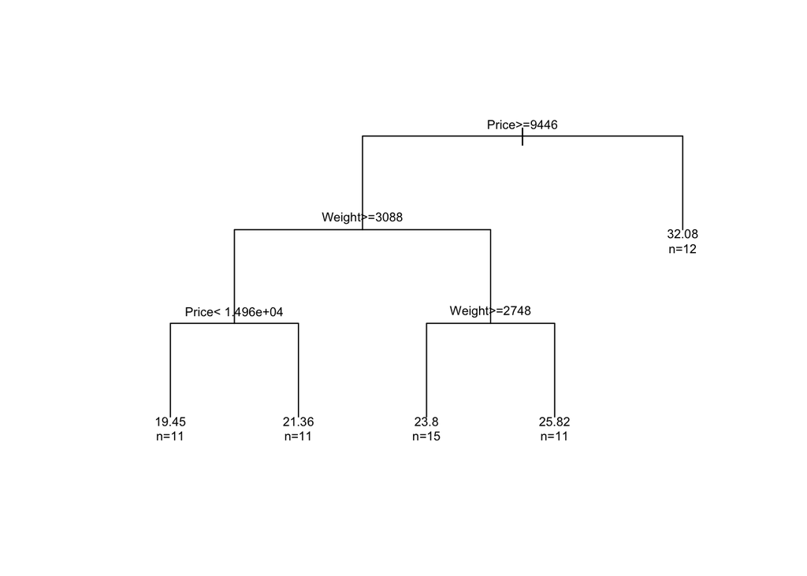

```r
plot(car.tree,uniform=TRUE,margin=0.1)
text(car.tree,cex=0.65, use.n=TRUE)
```

As can be seen in the tree, the Weight and Price variables are important to determine the Mileage, while Reliability is not. Also in the *summary()* the same information is shown.

```r
#Variable importance
#Price Weight
#54     46
summary(car.tree)
```

```
## Call:
## rpart(formula = Mileage ~ Weight + Price + Reliability, data = car.test.frame,
##     method = "anova")
##   n= 60
##
##           CP nsplit rel error    xerror       xstd
## 1 0.62288527      0 1.0000000 1.0383996 0.17612729
## 2 0.15850916      1 0.3771147 0.4732906 0.09326120
## 3 0.01908207      2 0.2186056 0.3016314 0.06427946
## 4 0.01479824      3 0.1995235 0.2909333 0.05640929
## 5 0.01000000      4 0.1847253 0.2889610 0.05821101
##
## Variable importance
##  Price Weight
##     54     46
##
## Node number 1: 60 observations,    complexity param=0.6228853
##   mean=24.58333, MSE=22.57639
##   left son=2 (48 obs) right son=3 (12 obs)
##   Primary splits:
##       Price       < 9446.5  to the right, improve=0.6228853, (0 missing)
##       Weight      < 2567.5  to the right, improve=0.5953491, (0 missing)
##       Reliability < 3.5     to the left,  improve=0.1263005, (11 missing)
##   Surrogate splits:
##       Weight < 2462.5  to the right, agree=0.95, adj=0.75, (0 split)
##
## Node number 2: 48 observations,    complexity param=0.1585092
##   mean=22.70833, MSE=8.498264
##   left son=4 (22 obs) right son=5 (26 obs)
##   Primary splits:
##       Weight      < 3087.5  to the right, improve=0.52636700, (0 missing)
##       Price       < 12154.5 to the right, improve=0.25748500, (0 missing)
##       Reliability < 3.5     to the left,  improve=0.01637086, (10 missing)
##   Surrogate splits:
##       Price < 13947   to the right, agree=0.854, adj=0.682, (0 split)
##
## Node number 3: 12 observations
##   mean=32.08333, MSE=8.576389
##
## Node number 4: 22 observations,    complexity param=0.01479824
```

[output cut: 15 more lines]

```
##       Reliability < 2.5     to the left,  improve=0.04061992, (5 missing)
##   Surrogate splits:
##       Price < 10710   to the right, agree=0.654, adj=0.182, (0 split)
##
## Node number 8: 11 observations
##   mean=19.45455, MSE=1.520661
##
## Node number 9: 11 observations
##   mean=21.36364, MSE=2.231405
##
## Node number 10: 15 observations
##   mean=23.8, MSE=4.026667
##
## Node number 11: 11 observations
##   mean=25.81818, MSE=4.14876
```

We could predict as we have done before: 1) train + test and 2) *predict()* function (not shown)

Finally, I recommend to save an image of all objects created in the session.

```r
save.image(file="R_Example_CART.RData")
```